# Analysis of red wine by Dilin John

#### 3) citric.acid content - positive correlation

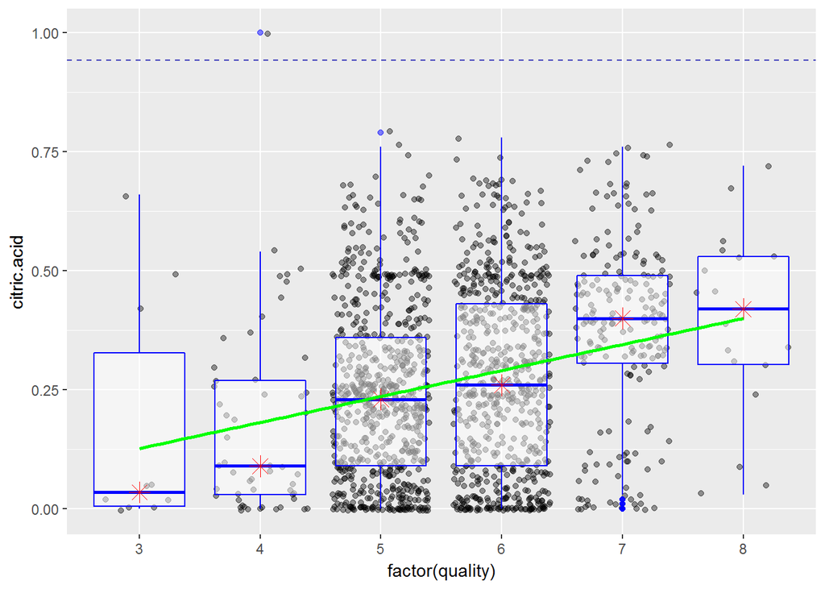

```r
box_scatter(redwine$citric.acid, 'citric.acid')
```

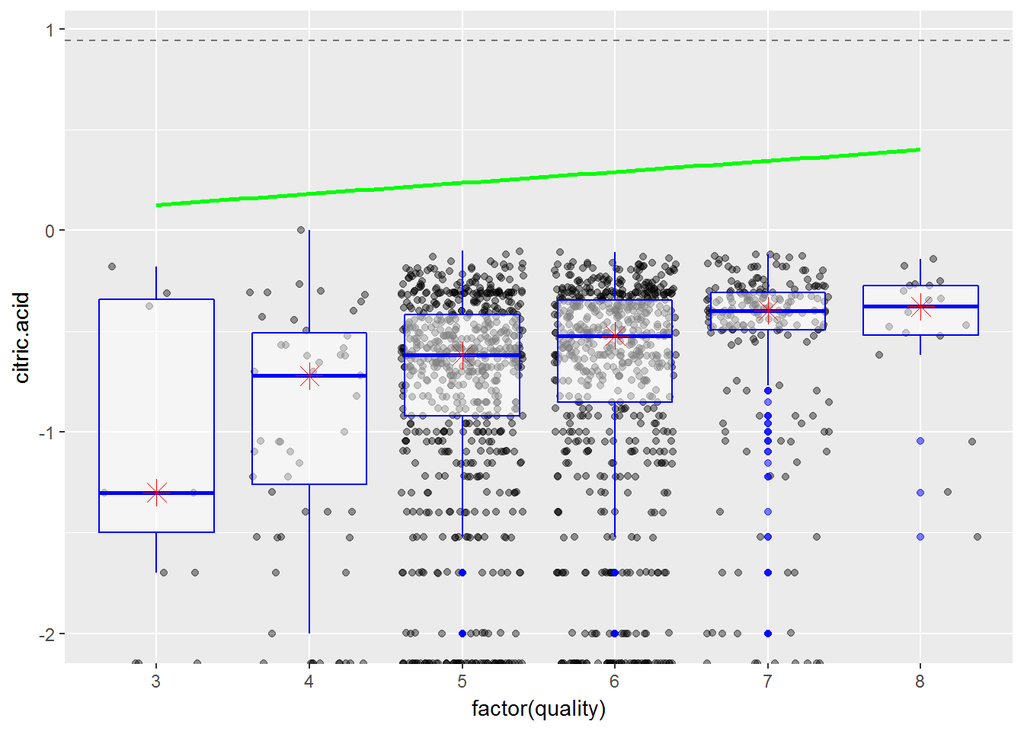

```r
box_scatter_log10(redwine$citric.acid, 'citric.acid')
```

```r
cor.test(redwine$citric.acid, redwine$quality)
```

```
##
##  Pearson's product-moment correlation
##
## data:  redwine$citric.acid and redwine$quality
## t = 9.2875, df = 1597, p-value < 2.2e-16
## alternative hypothesis: true correlation is not equal to 0
## 95 percent confidence interval:
##  0.1793415 0.2723711
## sample estimates:
##       cor
## 0.2263725
```

```r
cor.test(log10(redwine$citric.acid), redwine$quality)
```

```
##
##  Pearson's product-moment correlation
##
## data:  log10(redwine$citric.acid) and redwine$quality
## t = NaN, df = 1597, p-value = NA
## alternative hypothesis: true correlation is not equal to 0
## 95 percent confidence interval:
##  NaN NaN
## sample estimates:
## cor
## NaN
```

```r
stat_by_quality(redwine$citric.acid)
```

```
## redwine$quality: 3
##    Min. 1st Qu.  Median    Mean 3rd Qu.    Max.
##  0.0000  0.0050  0.0350  0.1710  0.3275  0.6600
## --------------------------------------------------------
## redwine$quality: 4
##    Min. 1st Qu.  Median    Mean 3rd Qu.    Max.
##  0.0000  0.0300  0.0900  0.1742  0.2700  1.0000
## --------------------------------------------------------
## redwine$quality: 5
##    Min. 1st Qu.  Median    Mean 3rd Qu.    Max.
##  0.0000  0.0900  0.2300  0.2437  0.3600  0.7900
## --------------------------------------------------------
## redwine$quality: 6
##    Min. 1st Qu.  Median    Mean 3rd Qu.    Max.
##  0.0000  0.0900  0.2600  0.2738  0.4300  0.7800
## --------------------------------------------------------
## redwine$quality: 7
##    Min. 1st Qu.  Median    Mean 3rd Qu.    Max.
##  0.0000  0.3050  0.4000  0.3752  0.4900  0.7600
## --------------------------------------------------------
## redwine$quality: 8
##    Min. 1st Qu.  Median    Mean 3rd Qu.    Max.
##  0.0300  0.3025  0.4200  0.3911  0.5300  0.7200
```

#### Let me check some of the negative correlations

volatile.acidity -0.39055778 used.sulfur.dioxide -0.20546298 total.sulfur.dioxide -0.18510029 density -0.17491923 pH -0.05773139

#### volatile.acidity

##### plots

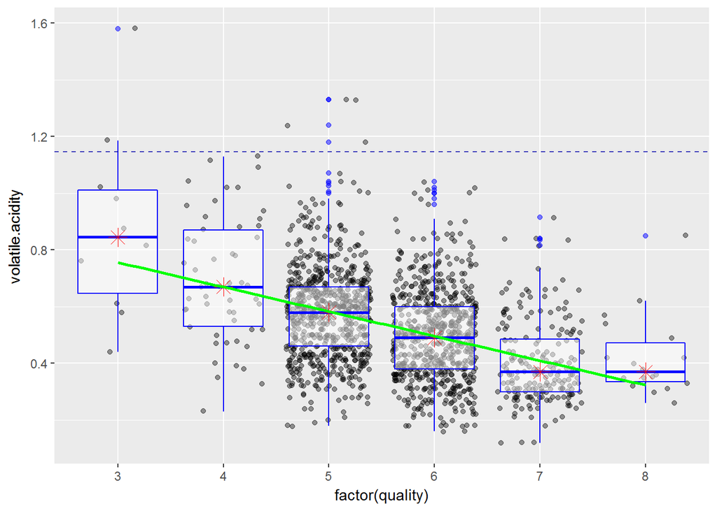

```r
box_scatter(redwine$volatile.acidity, 'volatile.acidity')
```

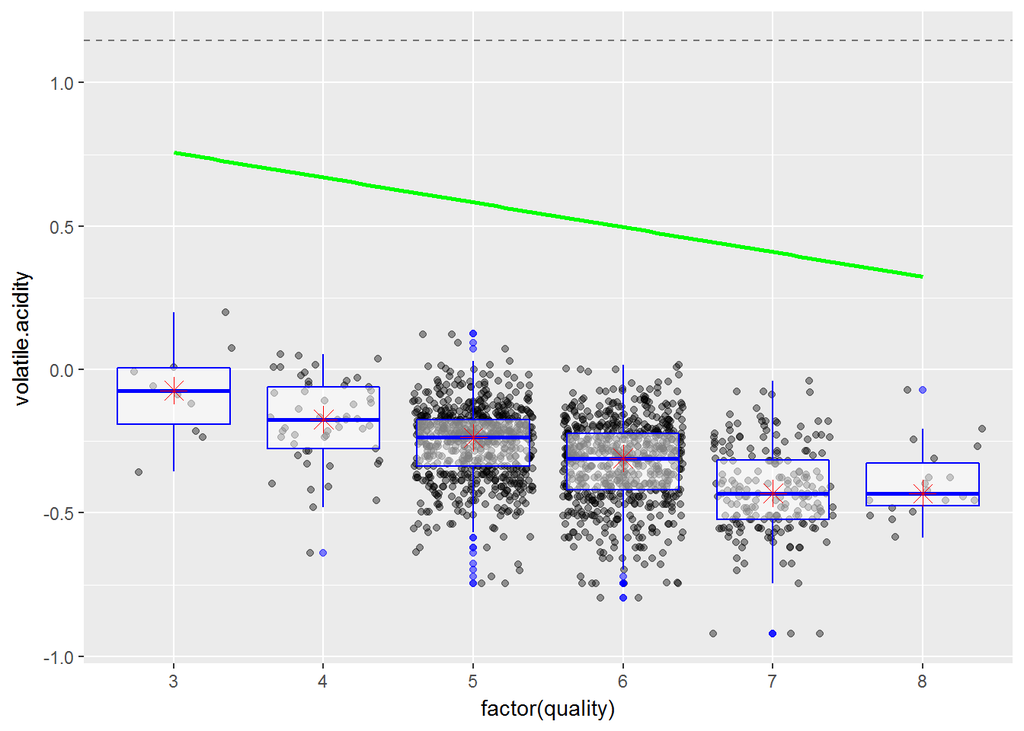

```r
box_scatter_log10(redwine$volatile.acidity, 'volatile.acidity')
```

```r
cor.test(redwine$volatile.acidity, redwine$quality)
```

```
##
##  Pearson's product-moment correlation
##
## data:  redwine$volatile.acidity and redwine$quality
## t = -16.954, df = 1597, p-value < 2.2e-16
## alternative hypothesis: true correlation is not equal to 0
## 95 percent confidence interval:
##  -0.4313210 -0.3482032
## sample estimates:
##        cor
## -0.3905578
```

```r
cor.test(log10(redwine$volatile.acidity), redwine$quality)
```

```
##
##  Pearson's product-moment correlation
##
## data:  log10(redwine$volatile.acidity) and redwine$quality
## t = -16.99, df = 1597, p-value < 2.2e-16
## alternative hypothesis: true correlation is not equal to 0
## 95 percent confidence interval:
##  -0.4319851 -0.3489201
## sample estimates:
##        cor
## -0.3912492
```

```r
stat_by_quality(redwine$volatile.acidity)
```

```
## redwine$quality: 3
##    Min. 1st Qu.  Median    Mean 3rd Qu.    Max.
##  0.4400  0.6475  0.8450  0.8845  1.0100  1.5800
## --------------------------------------------------------
## redwine$quality: 4
##    Min. 1st Qu.  Median    Mean 3rd Qu.    Max.
##   0.230   0.530   0.670   0.694   0.870   1.130
## --------------------------------------------------------
## redwine$quality: 5
##    Min. 1st Qu.  Median    Mean 3rd Qu.    Max.
##   0.180   0.460   0.580   0.577   0.670   1.330
## --------------------------------------------------------
## redwine$quality: 6
##    Min. 1st Qu.  Median    Mean 3rd Qu.    Max.
##  0.1600  0.3800  0.4900  0.4975  0.6000  1.0400
## --------------------------------------------------------
## redwine$quality: 7
##    Min. 1st Qu.  Median    Mean 3rd Qu.    Max.
##  0.1200  0.3000  0.3700  0.4039  0.4850  0.9150
## --------------------------------------------------------
## redwine$quality: 8
##    Min. 1st Qu.  Median    Mean 3rd Qu.    Max.
##  0.2600  0.3350  0.3700  0.4233  0.4725  0.8500
```

The box_scatter plot says it all. Negative relationship as expected from the correlation coefficient. What would be interesting to note is the lower grade wines have a higher IQR for the volatile acidity as complared to the higher grade wines. The higest quality wine of grade 8 has lowest IQR, with the median volatile acidity levels almost the same as grade 7, with much less IQR or disperion in the volatile acidity levels.

#### used.sulfur.dioxide

#### plots

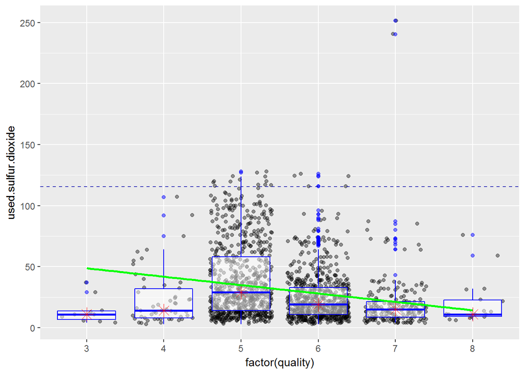

```r
box_scatter(redwine$used.sulfur.dioxide, 'used.sulfur.dioxide')
```

```r
#box_scatter_log10(redwine$used.sulfur.dioxide, 'used.sulfur.dioxide')
cor.test(redwine$used.sulfur.dioxide, redwine$quality)
```

```
##
##  Pearson's product-moment correlation
##
## data:  redwine$used.sulfur.dioxide and redwine$quality
## t = -8.3898, df = 1597, p-value < 2.2e-16
## alternative hypothesis: true correlation is not equal to 0
## 95 percent confidence interval:
##  -0.2519465 -0.1580336
## sample estimates:
##       cor
## -0.205463
```

```r
cor.test(log10(redwine$used.sulfur.dioxide), redwine$quality)
```

```
##
##  Pearson's product-moment correlation
##
## data:  log10(redwine$used.sulfur.dioxide) and redwine$quality
## t = -8.5109, df = 1597, p-value < 2.2e-16
## alternative hypothesis: true correlation is not equal to 0
## 95 percent confidence interval:
##  -0.2547209 -0.1609228
## sample estimates:
##        cor
## -0.2083007
```

```r
stat_by_quality(redwine$used.sulfur.dioxide)
```

```
## redwine$quality: 3
##    Min. 1st Qu.  Median    Mean 3rd Qu.    Max.
##    4.00    6.75   11.00   13.90   13.75   37.00
## --------------------------------------------------------
## redwine$quality: 4
##    Min. 1st Qu.  Median    Mean 3rd Qu.    Max.
##    3.00    8.00   14.00   23.98   32.00  107.00
## --------------------------------------------------------
## redwine$quality: 5
##    Min. 1st Qu.  Median    Mean 3rd Qu.    Max.
##    3.00   14.00   29.00   39.53   58.00  128.00
## --------------------------------------------------------
## redwine$quality: 6
##    Min. 1st Qu.  Median    Mean 3rd Qu.    Max.
##    3.00   11.00   19.00   25.16   33.00  126.00
## --------------------------------------------------------
## redwine$quality: 7
##    Min. 1st Qu.  Median    Mean 3rd Qu.    Max.
##    4.00    8.50   15.00   20.97   21.50  251.50
## --------------------------------------------------------
## redwine$quality: 8
##    Min. 1st Qu.  Median    Mean 3rd Qu.    Max.
##    6.00    9.25   11.00   20.17   22.75   76.00
```

From the box scatter plot, the trend we see quite matches with the negative correlation that we observed. What was intersting to note was the media count of the lowest grade was almost the same as the highest grade and this even had a lower IQR as compared to the grade 8 wine. This is quite strange. Also I noticed that the median count for grade 4 was almost equivalent to that of grade 7. There are some extreme outliers for grade 7, which is typically not expected from higher grade wines.

#### density

#### plots

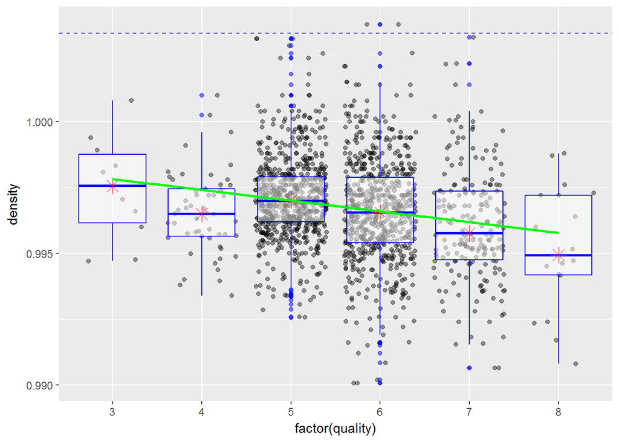

```r
box_scatter(redwine$density, 'density')
```

```r
#box_scatter_log10(redwine$density, 'density')
cor.test(redwine$density, redwine$quality)
```

```
##
##  Pearson's product-moment correlation
##
## data:  redwine$density and redwine$quality
## t = -7.0997, df = 1597, p-value = 1.875e-12
## alternative hypothesis: true correlation is not equal to 0
## 95 percent confidence interval:
##  -0.2220365 -0.1269870
## sample estimates:
##        cor
## -0.1749192
```

```r
cor.test(log10(redwine$density), redwine$quality)
```

```
##
##  Pearson's product-moment correlation
##
## data:  log10(redwine$density) and redwine$quality
## t = -7.1103, df = 1597, p-value = 1.74e-12
## alternative hypothesis: true correlation is not equal to 0
## 95 percent confidence interval:
##  -0.2222860 -0.1272452
## sample estimates:
##        cor
## -0.1751737
```

```r
stat_by_quality(redwine$density)
```

```
## redwine$quality: 3
##    Min. 1st Qu.  Median    Mean 3rd Qu.    Max.
##  0.9947  0.9961  0.9976  0.9975  0.9988  1.0008
## --------------------------------------------------------
## redwine$quality: 4
##    Min. 1st Qu.  Median    Mean 3rd Qu.    Max.
##  0.9934  0.9957  0.9965  0.9965  0.9974  1.0010
## --------------------------------------------------------
## redwine$quality: 5
##    Min. 1st Qu.  Median    Mean 3rd Qu.    Max.
##  0.9926  0.9962  0.9970  0.9971  0.9979  1.0031
## --------------------------------------------------------
## redwine$quality: 6
##    Min. 1st Qu.  Median    Mean 3rd Qu.    Max.
##  0.9901  0.9954  0.9966  0.9966  0.9979  1.0037
## --------------------------------------------------------
## redwine$quality: 7
##    Min. 1st Qu.  Median    Mean 3rd Qu.    Max.
##  0.9906  0.9948  0.9958  0.9961  0.9974  1.0032
## --------------------------------------------------------
## redwine$quality: 8
##    Min. 1st Qu.  Median    Mean 3rd Qu.    Max.
##  0.9908  0.9942  0.9949  0.9952  0.9972  0.9988
```

From the plots, the higher grade wines are seen to have a touch lower in density with median around 0.995, but still there appears to be more samples in upper IQR. The lower grade wines have the highest density and this I assume could be due to a higher water content as water density is 1.

#### pH

#### plots

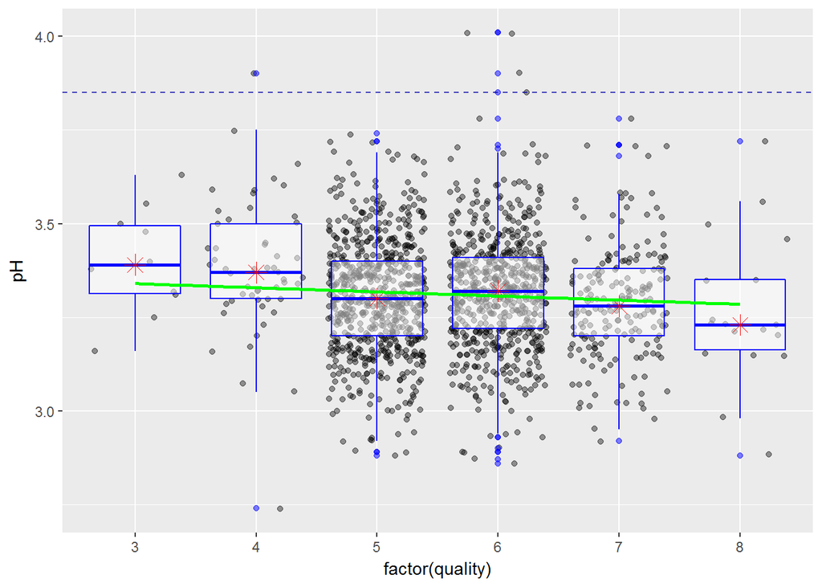

```r
box_scatter(redwine$pH, 'pH')
```

```r
#box_scatter_log10(redwine$pH, 'pH')
cor.test(redwine$pH, redwine$quality)
```

```
##
##  Pearson's product-moment correlation
##
## data:  redwine$pH and redwine$quality
## t = -2.3109, df = 1597, p-value = 0.02096
## alternative hypothesis: true correlation is not equal to 0
## 95 percent confidence interval:
##  -0.106451268 -0.008734972
## sample estimates:
##         cor
## -0.05773139
```

```r
cor.test(log10(redwine$pH), redwine$quality)
```

```
##
##  Pearson's product-moment correlation
##
## data:  log10(redwine$pH) and redwine$quality
## t = -2.3046, df = 1597, p-value = 0.02132
## alternative hypothesis: true correlation is not equal to 0
## 95 percent confidence interval:
##  -0.106294995 -0.008576923
## sample estimates:
##         cor
## -0.05757386
```

```r
stat_by_quality(redwine$pH)
```

```
## redwine$quality: 3
##    Min. 1st Qu.  Median    Mean 3rd Qu.    Max.
##   3.160   3.312   3.390   3.398   3.495   3.630
## --------------------------------------------------------
## redwine$quality: 4
##    Min. 1st Qu.  Median    Mean 3rd Qu.    Max.
##   2.740   3.300   3.370   3.382   3.500   3.900
## --------------------------------------------------------
## redwine$quality: 5
##    Min. 1st Qu.  Median    Mean 3rd Qu.    Max.
##   2.880   3.200   3.300   3.305   3.400   3.740
## --------------------------------------------------------
## redwine$quality: 6
##    Min. 1st Qu.  Median    Mean 3rd Qu.    Max.
##   2.860   3.220   3.320   3.318   3.410   4.010
## --------------------------------------------------------
## redwine$quality: 7
##    Min. 1st Qu.  Median    Mean 3rd Qu.    Max.
##   2.920   3.200   3.280   3.291   3.380   3.780
## --------------------------------------------------------
## redwine$quality: 8
##    Min. 1st Qu.  Median    Mean 3rd Qu.    Max.
##   2.880   3.163   3.230   3.267   3.350   3.720
```

#### Bivariate Analysis

citric acid and fixed acidity had a positive corrleation of 0.67 which is expected considering they are both acidic.Strong positive correlation between density and fixed acidity of 0.67 pH has a negative correlation with citric acid and fixed acidity levels as this was expected. A higher pH incidcate more alkaline nature.

Did you observe any interesting relationships between the other features (not the main feature(s) of interest)?

### What was the strongest relationship you found?

### Strongest correlation with quality was alcohol content 0.48. Other than that, there is a very strong correlation between acidic features like total.acidity, fixed.acidity and density